# assignment1

Correlation measures the strength and direction of a linear relationship between two random variables. It is a normalized value that always lies between -1 and +1.

Covariance measures how two variables vary together. - Positive covariance: as X increase, Y tends to increase. - Negative covariance: as X increase, Y tends to decrease.

Correlation is a scaled version of covariance, making it easier to interpret strength and relationships between two random variables.

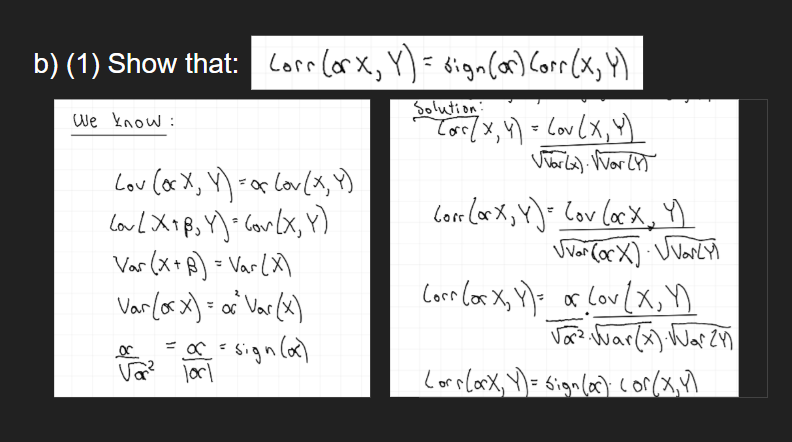

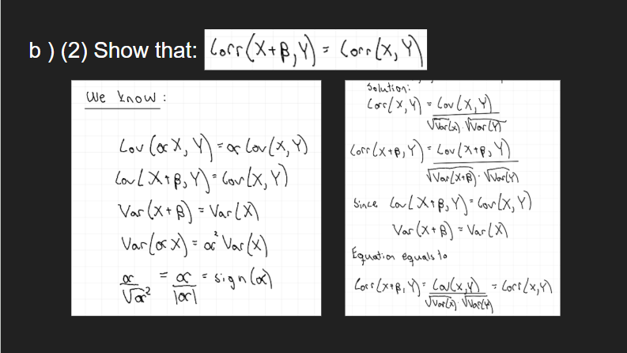

Comments on the first equation: - If you multiply X by a positive number, the correlation to Y doesn’t change. - If you multiply X with a negative number, the direction flips.

So correlation doesn’t care about the scale of measurments, only about the direction of the relationship.

Comments on the second equation: - If you add a constant to all values of X, the correlation with Y is unchanged.

Correlation ignores constant shifts, it only cares about how variablies vary together.

So in the big picture, Correlation only depends on the pattern of variation between two variables, not on the units or the baseline. Scaling can flip the sign, but otherwise, it stays the same.

Left side: correlation between x and y when z variable is controlled.

Right side: - numerator: correlation between x and y minus correlation_xz*correlationy_y<. So we subtract the indirect correlation between X and Y that comes from both being related to Z.

-denominator: normalizes so result is between -1 and +1.

- p_xy given z = 0: no link between X and Y once we control Z.
- p_xy given z > 0: positive correlation
- p_xy given z < 0 : negative correlation

So partial correlation measures the true direct link between two variables while filtering out the influnce of a third.

Three examples where partial correlation is useful:

1. X = Education level Y = Income Z = Age Education and income positively correlated, but older people have more education and higher income.
2. X = Hours of exercise per week Y = Body weight Z = Daily calorie intake

More exercise might correlate weakly with lower body weight, but people who exercise more may also eat more calories.

X = Season (autumn vs. winter) Y = Presentation quality (bad vs. good) Z = Exposure to more presentations from other students

Without controlling for Z, it could look like: Presentations are “worse” in fall and “better” in winter. Maybe we blame laziness from the summer, is there a Christmas magic force?

But when we control for Z, how many presentations students have already seen, we might find:

Presentation quality improves simply because students learn by watching more classmates present earlier in the semester.

The seasonal effect disappears, so there is no real Christmas force.

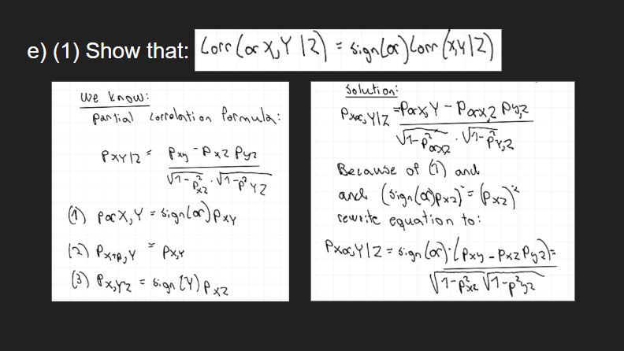

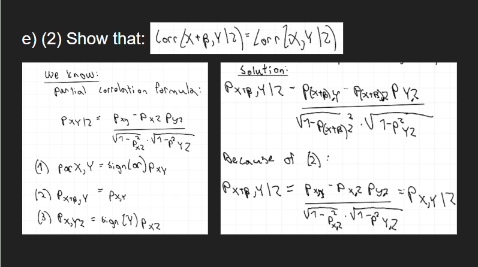

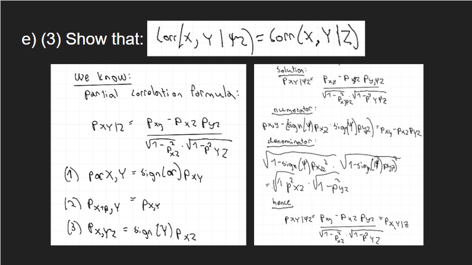

If you rescale X by a positive number, the partial correlation with Y (after controlling for Z) doesn’t change. If you flip the scale with a negative number , then the direction of the relationship flips, but the strength stays the same.

Changing the units or orientation of X doesn’t affect the relationship’s strength, only its sign if you flip the axis.

2. If you shift X by adding a constant, the partial correlation with Y is unchanged.

This is because correlation only cares about how variables vary together, not about their absolute levels.

Adding a constant to X doesn’t change how it co-moves with Y once Z is accounted for.

3. If you rescale Z, the result is the same.

Even flipping it only changes direction for Z itself, but the controlled relationship between X and Y remains identical.

The variable you control for works the same no matter how it’s scaled — correlation between X and Y after removing Z’s influence is unaffected